# Practical session: Fitting a deterministic model with MCMC

# Sampling from a simple distribution

In principle, we can use the Metropolis-Hastings sampler to sample from any target distribution. Let us test this: imagine you didn’t know how to draw random numbers from a normal distribution. You could use the Metropolis-Hastings sampler to do this. In **R**, the function to evaluate the probability density of a number under a normal distribution is called `dnorm`. It looks like this

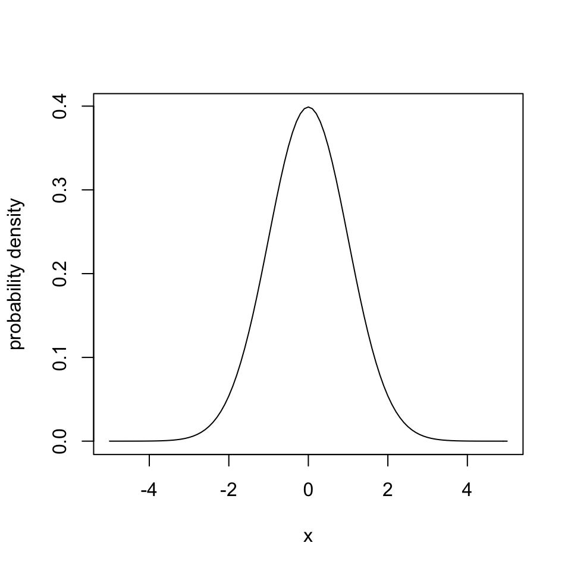

```r
plot(dnorm,
     xlim = c(-5, 5),
     ylab = "probability density")
```

We want to generate random numbers that follow the same distribution. There is one small extra step we have to do before we can sample from `dnorm`. Remember that we have set up the Metropolis-Hastings sampler above to expect the target distribution to return the logarithm of the probability density, whereas `dnorm`, by default, returns the (un-logged) probability density.

We can, however, instruct `dnorm` to return the logarithm of the probability density using the argument `log = TRUE`, and we use a *wrapper* function to do so. To sample, for example, from a normal distribution centred around 0, with standard deviation 1, we define a function that takes one argument and returns the logarithm of the probability density at the argument from such a normal distribution

```r
dnorm.log <- function(theta) {
   return(dnorm(x = theta, mean = 0, sd = 1, log = TRUE))
}
```

We can now sample from `dnorm.log` using our MCMC sampler

```r
starting.value <- 1 # starting value for MCMC
sigma <- 1 # standard deviation of MCMC
iter <- 1000
trace <- my_mcmcMH(target = dnorm.log, init.theta = starting.value,
   proposal.sd = sigma, n.iterations = iter)
```

We will talk later about diagnosing the trace (i.e., the sequence of samples) of an MCMC run. For now, you can visualise the trace of your MCMC run using

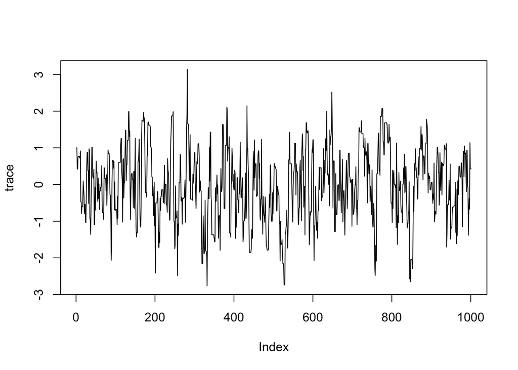

```r
plot(trace, type = "l")
```

And you can plot a histogram of the samples generated using

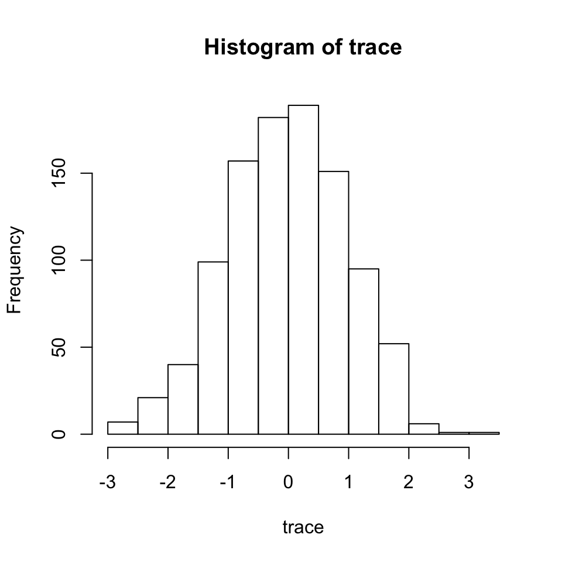

```r
hist(trace)
```

Of course, since MCMC is based on sampling random numbers, your plot will look different.

This examples looks reassuringly similar to the normal distribution centred around 0. Try different values for `init.theta` and `proposal.sd`. How do these affect the plots of the trace and the histogram? For more information you can also look at our discussion of this.

# Sampling from a posterior distribution

We can now use our Metropolis-Hastings sampler to sample from the posterior distribution(s) of the previous practical. You should have a `my_logPosterior` function that evaluates the posterior distribution at a given value of the parameters and initial state, for a given model and with respect to a given data set (if you don’t have this function, you can use the one from our solution). Again, we need to slightly adapt this to be able to explore it with our Metropolis-Hastings sampler.

Remember that we wrote `my_mcmcMH` to explore a single parameter. Our simplest SIR model, however has two parameters: the basic reproduction number $R_0$ and the duration of infection $D_\mathrm{inf}$. For now, we want to keep the duration of infection fixed at 2 and just explore the posterior distribution as a function of $R_0$. We can do this by setting `sd.proposal` to a vector of standard deviations, where the second element (if `D.inf` is the second parameter in `theta`) is 0.

Lastly, `my_logPosterior` takes four parameters, and to use it with the `my_mcmcMH` function we have to turn it into a function that just takes one parameter `theta`. Again, we use a wrapper function for this, which returns the posterior density for a given value of `theta` for the `SIR` model with respect to the `epi1` data set, and for fixed `init.state` ($X_0$).

```r
my_logPosterior_epi1 <- function(theta) {

  return(my_logPosterior(fitmodel = SIR,
     theta = theta,
     init.state = c(S = 999, I = 1, R = 0),
     data = epi1))
}
```

We can test that this function returns the value of the posterior for a given value of $R_0$.

```r
my_logPosterior_epi1(c(R0 = 3, D.inf = 2))
```

```
## [1] -3776.607
```

You should get the same number unless you changed the `SIR$pointLogLike` function.

We can now generate samples from `my_logPosterior_epi1` using `my_mcmcMH`. Can you work out the command to do this? If you have any problems with this, have a look at our solution.

Once you have generated the samples from the posterior distribution, you can calculate summary statistics such as the sample mean of $R_0$ (using `mean(trace[, 1])`), sample median (using `median(trace[, 1])`), 95% credible intervals (using `quantile(trace[, 1], probs=c(0.025, 0.975))`) and other properties.

Try to re-run your MCMC with different values for `init.theta` (the starting values for $R_0$ and $D_\mathrm{inf}$), for `proposal.sd` (the standard deviation of the Gaussian proposal distribution $q(\theta'|\theta)$), and for `iter` (the number of iterations). Look at plots generated using `plot` and `hist` (see above), summary statistics and the acceptance rate. Check how the answers to the following questions depend on parameters:

1. What is your best estimate of $R_0$? Does this match your estimate from the previous session?
2. What determines the acceptance rate?
3. How many iterations do you need to get a good estimate for $R_0$?

In the next session we will look at all of these issues in more detail.

# Going further

Try changing the `my_mcmcMH` function to use different proposal distributions from a normal distributions (e.g., using `runif` or `rlnorm` instead of `rnorm`). How do these affect the three questions above (best estimate, acceptance rate, number of iterations needed)?

Top: Index Previous: Introduction Next: MCMC diagnostics